# Final Project

Data Science for Biologists, Spring 2021

Sergio Tlatenco

May 4, 2021

##### Thank you for a great semester Dr. Spielman! I started learning HTML to assist in a side-project of mine and I thank you for introducing me to the world of coding and Data Science!

### This dataset examines tuition and cost at colleges and universities across the country. It also includes data on the diversity of US schools and post-graduation pay associated with each school.

```r
## READ IN DATA
tuition_cost <- readr::read_csv('https://raw.githubusercontent.com/rfordatascience/tidytuesday/master/data/2020/2020-03-10/tuition_cost.csv')

tuition_income <- readr::read_csv('https://raw.githubusercontent.com/rfordatascience/tidytuesday/master/data/2020/2020-03-10/tuition_income.csv')

salary_potential <- readr::read_csv('https://raw.githubusercontent.com/rfordatascience/tidytuesday/master/data/2020/2020-03-10/salary_potential.csv')

historical_tuition <- readr::read_csv('https://raw.githubusercontent.com/rfordatascience/tidytuesday/master/data/2020/2020-03-10/historical_tuition.csv')

diversity_school <- readr::read_csv('https://raw.githubusercontent.com/rfordatascience/tidytuesday/master/data/2020/2020-03-10/diversity_school.csv')


## Preview data
glimpse(tuition_cost)
```

```
## Rows: 2,973
## Columns: 10
## $ name                 <chr> "Aaniiih Nakoda College", "Abilene Christian Uni…
## $ state                <chr> "Montana", "Texas", "Georgia", "Minnesota", "Cal…
## $ state_code           <chr> "MT", "TX", "GA", "MN", "CA", "CO", "NY", "NY", …
## $ type                 <chr> "Public", "Private", "Public", "For Profit", "Fo…
## $ degree_length        <chr> "2 Year", "4 Year", "2 Year", "2 Year", "4 Year"…
## $ room_and_board       <dbl> NA, 10350, 8474, NA, 16648, 8782, 16030, 11660, …
## $ in_state_tuition     <dbl> 2380, 34850, 4128, 17661, 27810, 9440, 38660, 53…
## $ in_state_total       <dbl> 2380, 45200, 12602, 17661, 44458, 18222, 54690, …
## $ out_of_state_tuition <dbl> 2380, 34850, 12550, 17661, 27810, 20456, 38660, …
## $ out_of_state_total   <dbl> 2380, 45200, 21024, 17661, 44458, 29238, 54690, …
```

```r
glimpse(tuition_income)
```

```
## Rows: 209,012
## Columns: 7
## $ name        <chr> "Piedmont International University", "Piedmont Internatio…
## $ state       <chr> "NC", "NC", "NC", "NC", "NC", "NC", "NC", "NC", "NC", "NC…
## $ total_price <dbl> 20174, 20174, 20174, 20174, 20514, 20514, 20514, 20514, 2…
## $ year        <dbl> 2016, 2016, 2016, 2016, 2017, 2017, 2017, 2017, 2017, 201…
## $ campus      <chr> "On Campus", "On Campus", "On Campus", "On Campus", "On C…
## $ net_cost    <dbl> 11475.00, 11451.00, 16229.00, 15592.00, 11668.39, 11643.9…
## $ income_lvl  <chr> "0 to 30,000", "30,001 to 48,000", "48_001 to 75,000", "7…
```

```r
glimpse(salary_potential)
```

```
## Rows: 935
## Columns: 7
## $ rank                      <dbl> 1, 2, 3, 4, 5, 6, 7, 8, 9, 10, 11, 12, 13, …
## $ name                      <chr> "Auburn University", "University of Alabama…
## $ state_name                <chr> "Alabama", "Alabama", "Alabama", "Alabama",…
## $ early_career_pay          <dbl> 54400, 57500, 52300, 54500, 48400, 46600, 4…
## $ mid_career_pay            <dbl> 104500, 103900, 97400, 93500, 90500, 89100,…
## $ make_world_better_percent <dbl> 51, 59, 50, 61, 52, 53, 48, 57, 56, 58, 60,…
## $ stem_percent              <dbl> 31, 45, 15, 30, 3, 12, 27, 17, 17, 20, 8, 7…
```

```r
glimpse(historical_tuition)
```

```
## Rows: 270
## Columns: 4
## $ type         <chr> "All Institutions", "All Institutions", "All Institution…
## $ year         <chr> "1985-86", "1985-86", "1985-86", "1985-86", "1985-86", "…
## $ tuition_type <chr> "All Constant", "4 Year Constant", "2 Year Constant", "A…
## $ tuition_cost <dbl> 10893, 12274, 7508, 4885, 5504, 3367, 13822, 16224, 7421…
```

```r
glimpse(diversity_school)
```

```
## Rows: 50,655
## Columns: 5
## $ name             <chr> "University of Phoenix-Arizona", "University of Phoe…
## $ total_enrollment <dbl> 195059, 195059, 195059, 195059, 195059, 195059, 1950…
## $ state            <chr> "Arizona", "Arizona", "Arizona", "Arizona", "Arizona…
## $ category         <chr> "Women", "American Indian / Alaska Native", "Asian",…
## $ enrollment       <dbl> 134722, 876, 1959, 31455, 13984, 1019, 58209, 19039,…
```

## Question 1

#### Is private, for-profit, or public education cheaper in the Northeast or Southeast region of the U.S?

### Methods

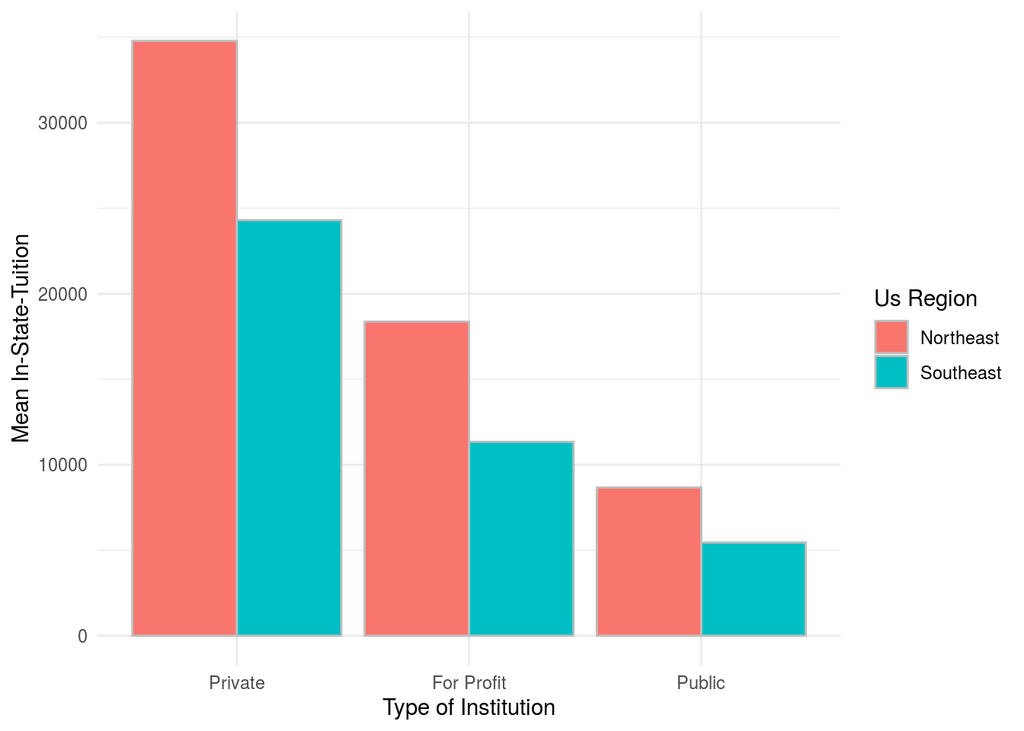

```r
# create variable w/ northeast states
northeast <- c("Connecticut", "Maine", "Massachusetts", "New Hampshire", "New Jersey", "New York", "Pennsylvania", "Rhode Island", "Vermont")

# create variable w/ southeast states
southeast <- c("Alabama", "Florida", "Georgia", "Arkansas", "Louisiana", "Mississippi", "North Carolina", "South Carolina", "Tennessee")

# create variable combining states from previous variables
interest_states <- c(northeast, southeast)

# start pipeline w/ appropriate data
tuition_cost %>%
  # filter for states in specified regions using saved variable combining vectors
  filter(state %in% interest_states) %>%
  # pipe mutate function to create a column that labels school by region
  mutate(us_region = if_else(state %in% northeast, "Northeast", "Southeast")) %>%
  # group schools by reigon and type of institution
  group_by(us_region, type) %>%
  # summarize by mean in state tuition under named column
  summarise(mean_in_state_tuition= mean(in_state_tuition)) %>%
  # pipe ggplot()
  ggplot() +
  # add aes w/ x reordered and fill mapped to us_region
  aes(x = reorder(type, -mean_in_state_tuition),
      y = mean_in_state_tuition,
      fill = us_region) +
  # add geom_col w/ position argument
  geom_col(position = "dodge",
           color = "gray") +
  # add custom theme
  theme_minimal() +
  # edit labels
  labs(x = "Type of Institution",
       y = "Mean In-State-Tuition",
       fill = "Us Region")
```

### Answer

For the three types of institutions (private, for-profit, and public), higher education is cheaper in the `Southeast` as visualized by the plot.

## Question 2

#### How do (mean) early- and mid-career incomes compare between schools in the Northeast and Southeast regions?

### Methods

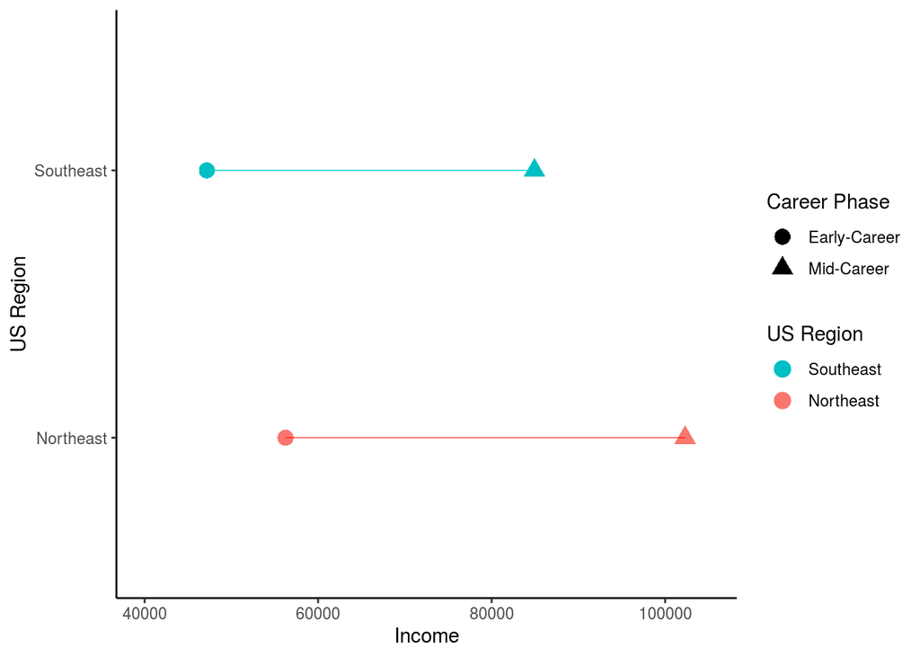

```r
# start pipeline w/ appropriate data
salary_potential %>%
  # filter for states in specified regions using saved variable combining vectors
  filter(state_name %in% interest_states) %>%
  # pipe mutate function to create a column that labels school by region
  mutate(us_region = if_else(state_name %in% northeast, "Northeast", "Southeast")) %>%
  # group subset by region
  group_by(us_region) %>%
  # use summarise function to group by mean of a column
  summarise(mean_early_career_pay = mean(early_career_pay),
            mean_mid_career_pay = mean(mid_career_pay)) %>%
  # use pivot_longer() to make data tidy
  pivot_longer(!us_region, names_to = "career_phase", values_to = "income") %>%
  # pipe ggplot()
  ggplot() +
  # add geom_point w/ color and shape mapped
  geom_point(size = 3.8,
               aes(y = us_region,
                   x = income,
                   color = us_region,
                   shape = career_phase)) +
  # add geom_segment for line between income data points
  geom_segment(aes(
      x = 56239.60,
      y = "Northeast",
      xend = 102302.97,
      yend = "Northeast"),
      size = 0.1,
      color = "red") +
  # add geom_segment for line between income data points
  geom_segment(aes(
      x = 47176.92,
      y = "Southeast",
      xend = 84937.18,
      yend = "Southeast"),
      size = 0.1,
      color = "cyan3") +
  # add custom theme
  theme_classic() +
  # edit x-axis limits for better visual
  xlim(40000, 105000) +
  # flip order of color legend for visual purposes
  guides(color = guide_legend(reverse = TRUE)) +
  # rename shape legend
  scale_shape_discrete(labels = c("Early-Career", "Mid-Career"),
                       name= "Career Phase") +
  # clean labels
  labs(x = "Income",
       y = "US Region",
       color = "US Region")
```

### Answer

The plot above shows that schools in the `Northeast` region have higher entry-level and mid-career incomes.

## Question 3

#### Which (race) category has the highest number of enrolled students in New Jersey?

### Methods

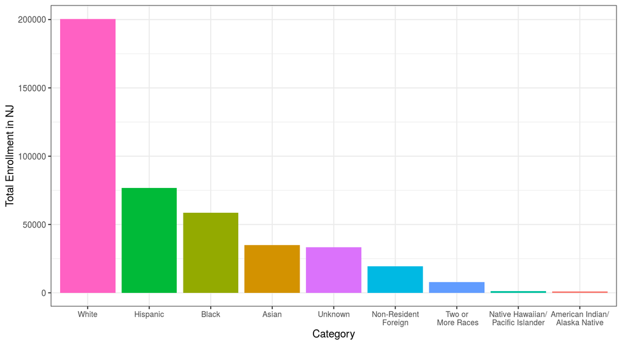

```r
# rename category labels w/ line breaks
new_labels <- c("White", "Hispanic", "Black", "Asian", "Unknown", "Non-Resident\nForeign", "Two or\n More Races", "Native Hawaiian/\nPacific Islander", "American Indian/\nAlaska Native")

# pipe appropriate data
diversity_school %>%
  # filter for NJ as state
  filter(state == "New Jersey") %>%
  # remove Total Minority from category column
  filter(category != "Total Minority") %>%
  # remove Women from category column
  filter(category != "Women") %>%
  # group subset by category
  group_by(category) %>%
  # summarize enrollment by category in new column
  summarise_at(vars(enrollment),
               list(total_enrolled = sum)) %>%
  # pipe ggplot()
  ggplot() +
  # add aes w/ x reordered and fill mapped to category
  aes(x = reorder(category, -total_enrolled), y = total_enrolled, fill = category) +
  # add columns
  geom_col() +
  # add custom theme
  theme_bw() +
  # remove legend and edit x axis text size
  theme(legend.position = "none", axis.text.x = element_text(size = 8)) +
  # change x axis names to saved variable w/ line breaks
  scale_x_discrete(labels = new_labels) +
  # change labels
  labs(x = "Category",
       y = "Total Enrollment in NJ")
```

### Answer

`White` students have the highest total enrollment in NJ colleges and universities and the plot made indicates disproportionate diversity.

## Question 4

#### Has there been a decrease in tuition cost at private or public institutions since 1985?

### Methods

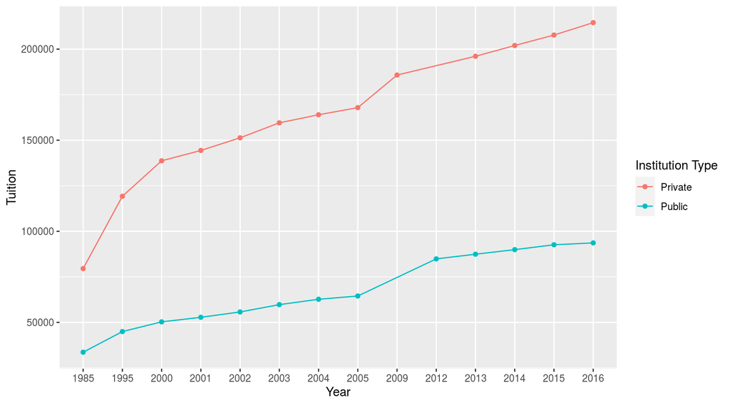

```r
# pipe appropriate data
historical_tuition %>%
  # remove All Institutions from type column
  filter(type != "All Institutions") %>%
  # remove column
  select(-tuition_type) %>%
  # group by specified columns
  group_by(year, type) %>%
  # mutate new column removing hyphen and numbers after hyphen in year column
  mutate(year = str_extract(year, "[0-9]{4}")) %>%
  # summarise tuition cost by year in new 'tuition' column
  summarise_at(vars(tuition_cost),
               list(tuition = sum)) %>%
  # pipe ggplot()
  ggplot() +
  # add aes w/ several arguments including color and group mapped to type
  aes(x = year,
      y = tuition,
      color = type,
      group = type) +
  # add scatterplot function
  geom_point() +
  # add line connection points
  geom_line() +
  # add custom theme
  theme_grey() +
  # edit labels
  labs(x = "Year",
       y = "Tuition",
       color = "Institution Type")
```

### Answer

Tuition costs at private and public instutions have not seen a decrease since 1985. Instead, tuition has been steadily increasing with `Private` institutions showing a faster rate of increase in tuition cost.